# Using a Canadian Cheese Dataset for Machine Learning - Final Project

*Author: Naod A.*

*Course: Introduction to Machine Learning | UBC Key Capabilities in Data Science*

## Introduction

Cheese, a phenomenal source of calcium and protein that boost bone and muscle health, but a nightmare for those who are highly lactose intolerant. In this project, machine learning concepts and techniques will be applied on a Canadian Cheese dataset for the purpose of understanding the data given and to develop models that can be used for predictions. Cheeses come in all shapes and sizes, with different milk types used in the production of cheese and the distinct flavours that each cheese have. My job in this project is to answer a specific question that I have formulated about the Cheese dataset, and this question can be seen below:

*Could we predict the category types for the cheese (Ex: soft, semi-soft, fresh) based on the moisture percentage?*

Now, this question seems to be best suited for classification since we are classifying a category type of the cheese. Moisture percentage, in my opinion, is the most suitable attribute from the Canadian Cheese dataset needed for category type classification because with moisture percentage, the softer the cheese, the higher the moisture percentage will be. So, a low moisture percentage for example would most likely indicate a cheese that is hard in nature. Overall, the values of the moisture percentage for each cheese, combined with the application of machine learning and the development of models, can help predict category types for cheeses. In the real world, the significance of this project would show how machine learning can be used not just with cheese datasets, but with general datasets involving food, and this can be incredibly helpful in the food sector when you want to come up with insights about certain food products.

By the end of this project, I would have developed a final machine learning model that can classify the category type of a given cheese based on its moisture percentage.

## Importing all the libraries for this project

Before we start, let's include all the libraries needed for this project.

```python
import altair as alt
import matplotlib.pyplot as plt
import numpy as np
import pandas as pd
from sklearn.compose import make_column_transformer
from sklearn.dummy import DummyClassifier
from sklearn.ensemble import RandomForestClassifier
from sklearn.linear_model import LogisticRegression
from sklearn.metrics import (
    ConfusionMatrixDisplay,
    classification_report,
    confusion_matrix,
    f1_score,
)
from sklearn.model_selection import (
    GridSearchCV,
    RandomizedSearchCV,
    cross_validate,
    train_test_split,
)
from sklearn.neighbors import KNeighborsClassifier
from sklearn.pipeline import make_pipeline
from sklearn.preprocessing import LabelEncoder, StandardScaler
from sklearn.svm import SVC
```

## Exploratory Data Analysis (EDA)

To begin, we will look at the **cheese_data.csv** dataset to understand the content inside this file. The content will be used for analysis to look at certain trends within the data, as well as issues within the data that pose problems during the analysis process.

### Reading the data in

The first step needed to perform an analysis on this dataset is to load in the data. We must convert it from a .csv file to a Pandas dataframe. When loading in the data, we will also specify that the first 5 rows are to be seen in the dataframe, so that we aren't looking at the entire dataframe, which would be too large.

```python
# Load the dataset
cheese_df = pd.read_csv("data/cheese_data.csv")

# Display the first 5 rows of the dataset
cheese_df.head(5)
```

|  | CheeseId | ManufacturerProvCode | ManufacturingTypeEn | MoisturePercent | FlavourEn | CharacteristicsEn | Organic | CategoryTypeEn | MilkTypeEn | MilkTreatmentTypeEn | RindTypeEn | CheeseName | FatLevel |
| --- | --- | --- | --- | --- | --- | --- | --- | --- | --- | --- | --- | --- | --- |
| 0 | 228 | NB | Farmstead | 47.0 | Sharp, lactic | Uncooked | 0 | Firm Cheese | Ewe | Raw Milk | Washed Rind | Sieur de Duplessis (Le) | lower fat |
| 1 | 242 | NB | Farmstead | 47.9 | Sharp, lactic, lightly caramelized | Uncooked | 0 | Semi-soft Cheese | Cow | Raw Milk | Washed Rind | Tomme Le Champ Doré | lower fat |
| 2 | 301 | ON | Industrial | 54.0 | Mild, tangy, and fruity | Pressed and cooked cheese, pasta filata, inter... | 0 | Firm Cheese | Cow | Pasteurized | NaN | Provolone Sette Fette (Tre-Stelle) | lower fat |
| 3 | 303 | NB | Farmstead | 47.0 | Sharp with fruity notes and a hint of wild honey | NaN | 0 | Veined Cheeses | Cow | Raw Milk | NaN | Geai Bleu (Le) | lower fat |
| 4 | 319 | NB | Farmstead | 49.4 | Softer taste | NaN | 1 | Semi-soft Cheese | Cow | Raw Milk | Washed Rind | Gamin (Le) | lower fat |

## Description of the dataset

Lets see a description of the dataset which details information such as the data types of each of the columns.

```python
cheese_df.info()  # shows information about the dataset
```

```
<class 'pandas.core.frame.DataFrame'>
RangeIndex: 1042 entries, 0 to 1041
Data columns (total 13 columns):
 #   Column                Non-Null Count  Dtype
---  ------                --------------  -----
 0   CheeseId              1042 non-null   int64
 1   ManufacturerProvCode  1042 non-null   object
 2   ManufacturingTypeEn   1042 non-null   object
 3   MoisturePercent       1028 non-null   float64
 4   FlavourEn             801 non-null    object
 5   CharacteristicsEn     643 non-null    object
 6   Organic               1042 non-null   int64
 7   CategoryTypeEn        1019 non-null   object
 8   MilkTypeEn            1041 non-null   object
 9   MilkTreatmentTypeEn   977 non-null    object
 10  RindTypeEn            721 non-null    object
 11  CheeseName            1042 non-null   object
 12  FatLevel              1042 non-null   object
dtypes: float64(1), int64(2), object(10)
memory usage: 106.0+ KB
```

We can also see descriptive statistics about the dataset.

```python
cheese_df.describe() # descriptive statistics about the dataset
```

|  | CheeseId | MoisturePercent | Organic |
| --- | --- | --- | --- |
| count | 1042.000000 | 1028.000000 | 1042.000000 |
| mean | 1560.633397 | 47.069747 | 0.095010 |
| std | 451.811164 | 9.592647 | 0.293369 |
| min | 228.000000 | 12.000000 | 0.000000 |
| 25% | 1280.250000 | 40.000000 | 0.000000 |
| 50% | 1548.500000 | 46.000000 | 0.000000 |
| 75% | 1901.750000 | 52.000000 | 0.000000 |
| max | 2391.000000 | 92.000000 | 1.000000 |

Before we go into depth with this project, it is important that we filter out any missing values contained in the dataset. Missing values can also be replaced with another value, depending on whether we are looking at a numeric or categorical column. If its a numeric column that we are dealing with, we want to replace the missing value with the mean, and if its a categorical column, we want to replace it with the mode.

```python
# find columns with missing values
missing_values_cols = cheese_df.columns[cheese_df.isna().any()]

# if its a numeric column, replace missing value with the mean value
numeric_cols = cheese_df.select_dtypes(include="number").columns
for num_col in numeric_cols:
    if num_col in missing_values_cols:
        cheese_df[num_col] = cheese_df[num_col].fillna(cheese_df[num_col].mean())

# for categorical columns, replace missing value with the mode
categorical_cols = cheese_df.select_dtypes(include=["object", "category"]).columns
for cat_col in categorical_cols:
    if cat_col in missing_values_cols:
        mode_value = cheese_df[cat_col].mode()[0]
        cheese_df[cat_col].fillna(mode_value, inplace=True)
```

```python
cheese_df
```

|  | CheeseId | ManufacturerProvCode | ManufacturingTypeEn | MoisturePercent | FlavourEn | CharacteristicsEn | Organic | CategoryTypeEn | MilkTypeEn | MilkTreatmentTypeEn | RindTypeEn | CheeseName | FatLevel |
| --- | --- | --- | --- | --- | --- | --- | --- | --- | --- | --- | --- | --- | --- |
| 0 | 228 | NB | Farmstead | 47.0 | Sharp, lactic | Uncooked | 0 | Firm Cheese | Ewe | Raw Milk | Washed Rind | Sieur de Duplessis (Le) | lower fat |
| 1 | 242 | NB | Farmstead | 47.9 | Sharp, lactic, lightly caramelized | Uncooked | 0 | Semi-soft Cheese | Cow | Raw Milk | Washed Rind | Tomme Le Champ Doré | lower fat |
| 2 | 301 | ON | Industrial | 54.0 | Mild, tangy, and fruity | Pressed and cooked cheese, pasta filata, inter... | 0 | Firm Cheese | Cow | Pasteurized | No Rind | Provolone Sette Fette (Tre-Stelle) | lower fat |
| 3 | 303 | NB | Farmstead | 47.0 | Sharp with fruity notes and a hint of wild honey | Creamy | 0 | Veined Cheeses | Cow | Raw Milk | No Rind | Geai Bleu (Le) | lower fat |
| 4 | 319 | NB | Farmstead | 49.4 | Softer taste | Creamy | 1 | Semi-soft Cheese | Cow | Raw Milk | Washed Rind | Gamin (Le) | lower fat |
| ... | ... | ... | ... | ... | ... | ... | ... | ... | ... | ... | ... | ... | ... |
| 1037 | 2387 | NS | Farmstead | 37.0 | Dill, Caraway, Chili Pepper, Cumin, Sage, Chiv... | Fresh curds through a variety of added Organic... | 1 | Hard Cheese | Cow | Pasteurized | No Rind | Knoydart | higher fat |
| 1038 | 2388 | AB | Industrial | 46.0 | Mild and Deep Flavor | Low in Sodium and Fat | 0 | Fresh Cheese | Cow | Pasteurized | No Rind | FRESK-O | lower fat |
| 1039 | 2389 | NS | Artisan | 40.0 | Grassy tang and restrained saltiness that refl... | Creamy | 0 | Veined Cheeses | Ewe | Thermised | No Rind | Electric Blue | higher fat |
| 1040 | 2390 | NS | Artisan | 34.0 | Sweet and tangy flavours combine with hoppy no... | Creamy | 0 | Semi-soft Cheese | Ewe | Thermised | Washed Rind | Hip Hop | higher fat |
| 1041 | 2391 | AB | Artisan | 31.5 | Available in different flavor: original, herb ... | Soft Squeaky Fresh Cheese. | 0 | Fresh Cheese | Cow | Pasteurized | No Rind | Super Fresh Cheese Curds | higher fat |

1042 rows × 13 columns

The dataframe now looks complete after replacing missing values with either a mean value for a numeric column, or a mode for categorical columns. Now, if we look at all these columns, there are really two columns that are needed to answer the question stated in the Introduction section. These columns are MoisturePercent (feature) and CategoryTypeEn (target).

```python
columns_to_drop = [
    "CheeseId",
    "ManufacturerProvCode",
    "ManufacturingTypeEn",
    "FlavourEn",
    "CharacteristicsEn",
    "Organic",
    "MilkTypeEn",
    "MilkTreatmentTypeEn",
    "RindTypeEn",
    "CheeseName",
    "FatLevel",
]

cheese_newdf = cheese_df.drop(columns=columns_to_drop)
cheese_newdf
```

|  | MoisturePercent | CategoryTypeEn |
| --- | --- | --- |
| 0 | 47.0 | Firm Cheese |
| 1 | 47.9 | Semi-soft Cheese |
| 2 | 54.0 | Firm Cheese |
| 3 | 47.0 | Veined Cheeses |
| 4 | 49.4 | Semi-soft Cheese |
| ... | ... | ... |
| 1037 | 37.0 | Hard Cheese |
| 1038 | 46.0 | Fresh Cheese |
| 1039 | 40.0 | Veined Cheeses |
| 1040 | 34.0 | Semi-soft Cheese |
| 1041 | 31.5 | Fresh Cheese |

1042 rows × 2 columns

Good, now that we have updated our dataset, lets look at some visualizations for it.

```python
# Plot that shows the frequency of a certain moisture percentage in a given cheese

MoisturePercentagePlot = (
    alt.Chart(cheese_newdf).mark_bar().encode(x="MoisturePercent", y="count()")
)

MoisturePercentagePlot
```

[interactive chart not shown]

Figure 1: Frequency of Moisture Percentages in cheeses listed in the dataset

This visualization above shows what are the most common moist percentages seen in each cheese. In this case, most of our cheeses will have a moisture percentage falling in the ranges between 35% and 60%. Let's look at another visualization below.

```python
# Plot that shows the frequency among category types

CategoryTypesPlot = (
    alt.Chart(cheese_newdf).mark_bar().encode(x="CategoryTypeEn", y="count()")
)

CategoryTypesPlot
```

[interactive chart not shown]

Figure 2: Frequency of Cheese Category Types in the dataset

Now, this shows the most common category types of cheese, and according to this graph above, Firm Cheese is the most common category type in the dataset, while Veined Cheese is the least common type.

The third visualization below will show the average moisture percentage for each category type.

```python
# plot that shows the average moisture percentage for each category type

average_value = cheese_newdf.groupby("CategoryTypeEn")["MoisturePercent"].mean()
average_value_df = pd.DataFrame(average_value)
average_df = average_value_df.reset_index()

AveragePlot = (
    alt.Chart(average_df).mark_bar().encode(x="CategoryTypeEn", y="MoisturePercent")
)

AveragePlot
```

[interactive chart not shown]

Figure 3: Average Moisture Percentage per Category Type

Back in the introduction, it was mentioned that the higher the moisture percentage is, the softer the cheese will be. This visualization mostly shows that, as you can see that soft cheese and fresh cheese are two of the types of cheeses that have a relatively higher moisture percentage average, whereas firm cheese and hard cheese have lower moisture percentages.

### Class imbalance

When looking at the dataset, I noticed that the number of category types in the dataset are not equal. For instance, in the second visualization above showing the frequency of category types in the dataset, it can be quickly noticed that the category type Firm Cheese is by far the most frequently occurring category type in the data. What this tells us is that the target column **CategoryTypeEn** is exhibiting a class imbalance, which means we could be making biased models that perform poorly on the category types that are not as frequent.

## Preprocessing

Lets look at our dataframe again.

```python
cheese_newdf
```

|  | MoisturePercent | CategoryTypeEn |
| --- | --- | --- |
| 0 | 47.0 | Firm Cheese |
| 1 | 47.9 | Semi-soft Cheese |
| 2 | 54.0 | Firm Cheese |
| 3 | 47.0 | Veined Cheeses |
| 4 | 49.4 | Semi-soft Cheese |
| ... | ... | ... |
| 1037 | 37.0 | Hard Cheese |
| 1038 | 46.0 | Fresh Cheese |
| 1039 | 40.0 | Veined Cheeses |
| 1040 | 34.0 | Semi-soft Cheese |
| 1041 | 31.5 | Fresh Cheese |

1042 rows × 2 columns

### Encode categorical labels

We need to encode the categorical labels into a numerical format by converting it into numerical labels using LabelEncoder because scikit-learn models require numerical inputs.

```python
le = LabelEncoder()
cheese_newdf["CategoryTypeEn_Encoded"] = le.fit_transform(
    cheese_newdf["CategoryTypeEn"]
)
```

### Defining features

Next, define the feature (X) and the target (y)

```python
# Separate features and labels
X = cheese_newdf[["MoisturePercent"]]  # Feature
y = cheese_newdf["CategoryTypeEn_Encoded"]  # Target
```

### Splitting the dataset into training and test sets

Now we can split the data into training and testing sets using an 80/20 split

```python
X_train, X_test, y_train, y_test = train_test_split(X, y, test_size=0.2)
```

## Column Transformer

The column "MoisturePercent" is a numerical column, so we should create a list called "numerical_feature" for it.

```python
numerical_feature = ["MoisturePercent"]
```

Since we are dealing with one numerical feature, we will define a column transformer with StandardScaler, which is used for numerical columns.

```python
numerical_transform = make_pipeline(StandardScaler())
```

Now we can define the column transformer

```python
cln_transformer = make_column_transformer((numerical_transform, numerical_feature))
```

## Developing Models

Preprocessing has been done. We can now move over to developing these models. We will first start with creating a baseline model with the *DummyClassifier*.

### Baseline model

```python
dummy = DummyClassifier(strategy="stratified")
dummy.fit(X_train, y_train)
dummy_score = pd.DataFrame(
    cross_validate(dummy, X_train, y_train, cv=5, return_train_score=True)
)
dummy_score
```

|  | fit_time | score_time | test_score | train_score |
| --- | --- | --- | --- | --- |
| 0 | 0.000791 | 0.000272 | 0.215569 | 0.285285 |
| 1 | 0.000387 | 0.000188 | 0.281437 | 0.246246 |
| 2 | 0.000365 | 0.000177 | 0.293413 | 0.252252 |
| 3 | 0.000374 | 0.000177 | 0.271084 | 0.257871 |
| 4 | 0.000350 | 0.000185 | 0.319277 | 0.236882 |

Because we are dealing with an imbalanced dataset, making **strategy = "stratfied"** would take the imbalance into account. Cross validation is done in 5-folds, and the results aren't very promising for this baseline model. Let's get the mean scores now.

```python
dummy_score.mean()
```

```
fit_time       0.000453
score_time     0.000200
test_score     0.276156
train_score    0.255707
dtype: float64
```

The test and training scores for the baseline DummyClassifier model are low, indicating that this model is too simple for this training data. Lets try a linear model approach with LogisticsRegression() next.

### Linear Model with LogisticsRegression()

```python
linear_pipe = make_pipeline(cln_transformer, LogisticRegression())
linear_score = pd.DataFrame(
    cross_validate(linear_pipe, X_train, y_train, cv=5, return_train_score=True)
)
linear_score
```

|  | fit_time | score_time | test_score | train_score |
| --- | --- | --- | --- | --- |
| 0 | 0.008687 | 0.001458 | 0.580838 | 0.611111 |
| 1 | 0.007251 | 0.001280 | 0.592814 | 0.609610 |
| 2 | 0.006993 | 0.001284 | 0.628743 | 0.600601 |
| 3 | 0.007632 | 0.001293 | 0.596386 | 0.608696 |
| 4 | 0.007168 | 0.001408 | 0.632530 | 0.599700 |

```python
linear_score.mean()
```

```
fit_time       0.007546
score_time     0.001345
test_score     0.606262
train_score    0.605943
dtype: float64
```

Both the test and training scores from this Linear model are much higher than the scores from the dummy model. The reason why it has done so much better than the dummy model is because linear models find patterns from the data it learns, whereas a baseline DummyClassifier model simply uses a baseline for measuring. Furthermore, given how there's a small gap between the test_score and the training_score, it means that this Linear Model doesn't significantly overfit and its quite good for this kind of dataset. However, lets explore with more models by starting with K-Nearest Neighbors.

### K-Nearest Neighbors Model

```python
knn = make_pipeline(cln_transformer, KNeighborsClassifier())
knn_score = pd.DataFrame(
    cross_validate(knn, X_train, y_train, cv=5, return_train_score=True)
)
knn_score
```

|  | fit_time | score_time | test_score | train_score |
| --- | --- | --- | --- | --- |
| 0 | 0.003438 | 0.003405 | 0.586826 | 0.626126 |
| 1 | 0.002685 | 0.003514 | 0.526946 | 0.572072 |
| 2 | 0.002856 | 0.003277 | 0.538922 | 0.567568 |
| 3 | 0.002664 | 0.003268 | 0.632530 | 0.629685 |
| 4 | 0.002683 | 0.003278 | 0.536145 | 0.571214 |

```python
knn_score.mean()
```

```
fit_time       0.002865
score_time     0.003348
test_score     0.564274
train_score    0.593333
dtype: float64
```

### Random Forest Classifier Model

```python
rfc = make_pipeline(cln_transformer, RandomForestClassifier())
rfc_score = pd.DataFrame(
    cross_validate(rfc, X_train, y_train, cv=5, return_train_score=True)
)
rfc_score
```

|  | fit_time | score_time | test_score | train_score |
| --- | --- | --- | --- | --- |
| 0 | 0.071269 | 0.006052 | 0.592814 | 0.663664 |
| 1 | 0.069425 | 0.005971 | 0.610778 | 0.663664 |
| 2 | 0.068850 | 0.006091 | 0.640719 | 0.653153 |
| 3 | 0.070822 | 0.006128 | 0.620482 | 0.659670 |
| 4 | 0.068973 | 0.006019 | 0.602410 | 0.652174 |

```python
rfc_score.mean()
```

```
fit_time       0.069868
score_time     0.006052
test_score     0.613441
train_score    0.658465
dtype: float64
```

Looking at the Random Forest Classifier model scores above, it has a higher test and training score than the K-Nearest Neighbours model, however, there is still a gap between the test score and training score. It indicates that it is more likely to significantly overfit like the K-Nearest Neighbours model. Finally, lets look at the SVC model.

### SVC Model

```python
svc = make_pipeline(cln_transformer, SVC())
svc_score = pd.DataFrame(
    cross_validate(svc, X_train, y_train, return_train_score=True)
)
svc_score
```

|  | fit_time | score_time | test_score | train_score |
| --- | --- | --- | --- | --- |
| 0 | 0.010751 | 0.003461 | 0.580838 | 0.623123 |
| 1 | 0.010472 | 0.003429 | 0.586826 | 0.624625 |
| 2 | 0.010635 | 0.003422 | 0.640719 | 0.612613 |
| 3 | 0.010000 | 0.003411 | 0.584337 | 0.625187 |
| 4 | 0.010760 | 0.003443 | 0.644578 | 0.602699 |

```python
svc_score.mean()
```

```
fit_time       0.010524
score_time     0.003433
test_score     0.607460
train_score    0.617649
dtype: float64
```

Similar to the Linear Model scores, there is a relatively small gap between the test and training score for this SVC model. However, SVC model has a slightly higher test and training score than Linear Model, so it can be said that the SVC model is slightly better than the Linear model for handling this dataset.

## Overview of the Machine Learning Models used

Overall, these were the 5 models looked at:

- Baseline DummyClassifier Model
- Linear Model with Logistics Regression
- K-Nearest Neighbours Model
- Random Forest Classifier Model
- SVC Model

Excluding the baseline model, all models seemed to have similar results, with a few of those models having smaller gaps in their training and test scores than others. I have concluded that the SVC model is the best model for this dataset. Therefore, I will go with the SVC model as my final model.

### Hyperparameter optimization

Lets look at the optimal parameters for the SVC model using GridSearchCV. Below is a predefined set of values for the hyperparameters, and GridSearchCV will go through each possible option and evaluate its performance using cross validate.

```python
param_grid = {
    "svc__C": [0.1, 1, 10, 100],
    "svc__gamma": [0.001, 0.01, 0.1, 1],
    "svc__kernel": ["rbf", "linear"],
}

grid_search = GridSearchCV(svc, param_grid, cv=5, return_train_score=True, n_jobs=3)
grid_search.fit(X_train, y_train)

grid_bestparams = grid_search.best_params_
grid_bestparams
```

```
{'svc__C': 10, 'svc__gamma': 0.001, 'svc__kernel': 'linear'}
```

According to GridSearchCV, the optimal values for the parameters are as listed above. With these optimal parameters now, we can develop the best version of this SVC model and make the classification matrix.

### Classification Matrix and Report

```
<sklearn.metrics._plot.confusion_matrix.ConfusionMatrixDisplay at 0x7f9fdc161f40>
```

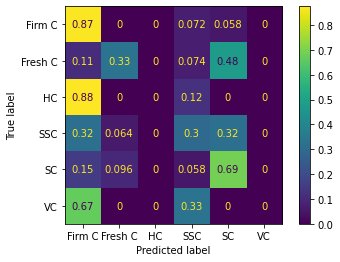

```python
optimal_svc_model = grid_search.best_estimator_
y_pred = optimal_svc_model.predict(X_test)

# Generate and display the confusion matrix
cm = confusion_matrix(y_test, y_pred, normalize="true")

reviews_cm = ConfusionMatrixDisplay(
    confusion_matrix=cm, display_labels=["Firm C", "Fresh C", "HC", "SSC", "SC", "VC"]
)
# Firm C = Firm Cheese
# Fresh C = Fresh Cheese
# HC = Hard Cheese
# SSC = Semi-soft cheese
# SC = Soft cheese
# VC = Veined Cheese

reviews_cm.plot()
```

Figure 4: Confusion matrix depicting the proportion of true positives, true negatives, false positives, and false negatives

According to the Classification matrix, we can see the following:

- Firm Cheese True Positive: 0.87
- Fresh Cheese True Positive: 0.33
- Hard Cheese True Positive: 0
- Semi-soft Cheese True Positive: 0.3
- Soft Cheese True Positive: 0.69
- Veined Cheese True Positive: 0

For each category type of cheese, the false negatives would fall on the **same row** as the true positive (horizontal), and the false positives would fall on the **same column** as the true positive (vertical). Everything else would be considered a true negative. Lets look at the classification report now.

```python
print(classification_report(y_test, y_pred))
```

```
              precision    recall  f1-score   support

           0       0.62      0.87      0.72        69
           1       0.53      0.33      0.41        27
           2       0.00      0.00      0.00         8
           3       0.52      0.30      0.38        47
           4       0.53      0.69      0.60        52
           5       0.00      0.00      0.00         6

    accuracy                           0.57       209
   macro avg       0.37      0.37      0.35       209
weighted avg       0.52      0.57      0.53       209
```

In the classification report, we can see that the f1 score in class 2 and class 5 are 0. In contrast, class 0 had an F1-score of 0.72, and class 4 had an F1-score of 0.60. Overall, the weighted F1-score of this final model is 0.53, which is the score of the weighted average of the F1 scores for each class. Its weighted according to the number of true instances per class listed under the Support column.

## Discussion

The objective of this project was to answer our specific question stated in the Introduction section: *Could we predict the category types for the cheese (Ex: soft, semi-soft, fresh) based on the moisture percentage?*

To answer the question, we needed to build a supervised machine learning model that would accurately predict the category type of the cheese based on its moisture percentage. By exploring various machine learning models, we ended up using the SVC model as our final model to answer our question. Did this model do well? With our classification report, we can see that the model's performance varied across classes, with performance being much better in some classes than others. With a weighted F1-score average of 0.53, it seems like there is room for improvement by exploring other machine learning algorithms. However, we need to take into account the imbalanced dataset that could be addressed in order for a model's performance to improve.

It also could be improved with more features. I initially wanted to use the **CharacteristicsEn** column from the dataset for this project because I saw descriptive words such as "creamy". When you think of cheese that is "creamy", you would think the cheese is relatively soft in nature. Therefore, I explored the idea of finding the most common word describing a cheese for each of the category types. However, when I got the results, the word "creamy" was the most common word across **all** category types. This was problematic because hard cheese was even being described as "creamy" in the dataset. So I decided not to pursue with using the **CharacteristicEn** column as my second feature, and stuck with values from the **MoisturePercentage** column instead.

Overall, this project provided me with the experience of utilizing machine learning models for prediction purposes to answer a specific question. In the real world, I can see this kind of machine learning model be helpful in classifying cheeses for distribution purposes. Perhaps a specific cheese with a certain moisture percentage must be distributed or handled differently to preserve it well.

## References

Introduction to Machine Learning. Module6-10-columntransformer – introduction to machine learning. (n.d.). https://ubc-mds.github.io/introduction-machine-learning/modules/module6/module6-10-columntransformer.html

Introduction to Machine Learning. Module6-18-handeling_categorical_features_binary_ordinal_and_more – introduction to machine learning. (n.d.). http://ubc-mds.github.io/introduction-machine-learning/modules/module6/module6-18-handeling_categorical_features:_binary_ordinal_and_more.html

Introduction to Machine Learning. Module7-16-regression_measurements – introduction to machine learning. (n.d.). https://ubc-mds.github.io/introduction-machine-learning/modules/module7/module7-16-regression_measurements.html